# Reintegrating Socializing in a Post-Pandemic World

Barien Gad, Illinois Institute of Technology[^1]

Alisha Khan, Illinois Institute of Technology[^2]

Aleksander Popovic, Illinois Institute of Technology[^3]

Mohammad Firas Sada, Illinois Institute of Technology[^4]

Fall 2023 SoReMo Fellowship Project Final Technical Report

[Back to journal](https://soremo.library.iit.edu)

# Executive Summary

In this research project, we address the pervasive issue of loneliness, significantly affecting the American population. Recognized as a pressing societal concern, even the U.S. Surgeon General has labeled it an epidemic. Loneliness poses severe health risks, including suicide, cardiovascular disease, dementia, stroke, depression, and anxiety. Moreover, it burdens the United States economically, costing an estimated $406 billion annually, with an additional $6.7 billion in Medicare expenses for socially isolated older adults.

However, addressing loneliness poses challenges for both society and the field of data science. Societally, the complexity of loneliness, as a subjective and variable experience, is a central challenge. Stigma often discourages individuals from seeking help or acknowledging their isolation. Social, economic, technological, and cultural factors further complicate mitigation efforts. Access to resources and effective policy development remain significant hurdles.

Within the realm of data science, unique complexities arise. Quantifying loneliness, a subjective and multifaceted emotion, is difficult. Data privacy and ethical concerns emerge when collecting and analyzing sensitive personal data related to social interactions and emotional states. Addressing loneliness requires collaboration between data scientists and experts in psychology, sociology, and health sciences. Algorithmic bias and fairness must be carefully considered. Integrating digital solutions with real-world interventions, ensuring user engagement, and measuring the long-term impact of technological interventions are additional obstacles. Balancing technology with preserving essential human interactions is crucial.

To combat social isolation, we introduce the “trifecta” model, a collaborative partnership among individual users, local businesses, and corporate sponsors. Individual users gain access to diverse local events, fostering community engagement and social connections. Local businesses, serving as event venues, benefit from increased foot traffic and visibility. Corporate sponsors finance these events, leveraging direct marketing and consumer engagement opportunities. This model addresses social isolation, revitalizes local economies, and introduces a novel approach to corporate marketing.

In this research paper, we delve into the multifaceted issue of loneliness, exploring its effects and proposing potential solutions. We begin by examining the profound impact of loneliness on individuals, particularly its association with mental and physical health challenges. Our focus then shifts to the role of social gatherings in mitigating loneliness.

Through our research, we have identified a significant contrast: while social media often exacerbates feelings of loneliness, gathering in real-world settings plays a crucial role in reducing it. However, we recognize a concerning trend: the decline of “third spaces”—neutral gathering places outside of home and work—has created barriers to socializing, intensifying loneliness.

This realization led us to investigate existing solutions like Meetup.com, revealing their limitations, particularly the lack of free, tailored events. Consequently, we sought to address the question: How can we make social events more accessible and free for everyone?

Our proposed solution leverages the interests of companies seeking to engage their target audience while bypassing the saturated online marketing landscape. By sponsoring free events, companies can directly connect with potential customers in a meaningful way. To ensure these events attract the intended audience, we developed an algorithm to match users with events based on their unique interests.

To implement this solution, we curated a comprehensive dataset encompassing event and user information. We then created a neural network model to predict user attendance at events based on their interests.

Finally, recognizing the need for a user-friendly platform, we determined that a mobile app would be the most effective way to connect users with events, providing a holistic solution to address the pervasive issue of loneliness.

# Technical Details

## The Problem of Loneliness

### The Effects of Loneliness

Loneliness is a critical public health issue, as it exerts significant adverse effects on both physical and mental health. Extensive research has consistently demonstrated a range of detrimental impacts associated with loneliness.

- Physical Health Effects: Loneliness is closely linked to poorer physical health outcomes. Individuals experiencing loneliness face a higher risk of developing cardiovascular diseases, dementia, and accelerated cognitive decline. Additionally, they have an increased risk of mortality. Loneliness is also associated with elevated blood pressure, weight gain, and a greater likelihood of engaging in unhealthy behaviors such as smoking and excessive alcohol or drug use (Richard et al. 2017). These physical health consequences underscore the urgency of addressing loneliness as a public health concern (Finley and Schaefer 2022; Berg-Weger and Morley 2020).
- Mental Health Effects: Loneliness significantly contributes to mental health challenges, including depression, anxiety, and reduced well-being. This impact is particularly pronounced in older adults, who may experience more severe depressive and anxious symptoms due to loneliness (Bekhet and Zauszniewski 2012).
- Risk of Chronic Conditions: Loneliness is an independent risk factor for various chronic conditions, both physical and psychiatric. These include cardiovascular disease, diabetes mellitus, cancer, cognitive impairment, immune system dysfunction, and a range of mental health disorders (Crewdson 2016; Pai and Vella 2022). Recognizing loneliness as a risk factor highlights the need for early intervention and prevention.
- Impact on Quality of Life: Loneliness substantially diminishes an individual’s quality of life, mediated by factors such as mental health and resilience (Gerino et al. 2017). This effect is observed across diverse age groups and populations, underscoring loneliness’s pervasive nature as a public health concern.
- Biological Factors: Loneliness has complex biological underpinnings, as it can correlate with changes in stress hormones, immune system components, and the glutamate system. These biological markers highlight the intricate interplay between loneliness and the body’s physiological processes (Campagne 2019). Understanding these biological mechanisms is crucial for developing targeted interventions and treatments for individuals experiencing loneliness.

### How Has Social Media Disconnected People More?

In the digital age, the relationship between social media and loneliness, particularly among adolescents, has become increasingly complex. While social media platforms offer unprecedented connectivity, research suggests they may also contribute to feelings of isolation and disconnection.

A study by Twenge et al. (2019) revealed a correlation between high social media use among adolescents and reduced in-person social interaction, leading to increased feelings of loneliness. This paradox suggests that despite being highly connected online, adolescents may experience a decline in the real-world interactions crucial for their social and emotional development. The often superficial nature of online communication can fail to provide the depth and intimacy of face-to-face interactions, potentially contributing to a sense of isolation.

The COVID-19 pandemic further highlighted this issue. Research by Boursier et al. (2020) found that excessive social media use during the pandemic predicted heightened loneliness and anxiety. This may be attributed to the forced reliance on digital communication in lieu of in-person contact, which can lack the emotional fulfillment derived from physical presence. Additionally, a study by Helm et al. (2022) revealed that while social media use could mitigate feelings of existential isolation during the pandemic, it also intensified emotional loneliness due to the increased awareness of missing loved ones and the inability to connect physically.

These findings underscore how extraordinary circumstances, such as a global pandemic, can amplify the potential negative effects of social media on mental well-being. In an era defined by increasing digital connectivity, it is crucial to understand the delicate balance between social media use and its potential to foster or hinder genuine social connection. Striking this balance is essential for promoting overall well-being in an increasingly digitized world.

## How Does Gathering Help?

Research consistently demonstrates the significant role of social gatherings and increased social interaction in mitigating feelings of loneliness across diverse age groups and contexts. These studies emphasize the importance of fostering meaningful social connections and interactions to address loneliness and enhance mental well-being.

Santini et al. (2016) highlighted the effectiveness of interventions aimed at enhancing relationship quality and strengthening social networks in reducing loneliness among older adults. Their research emphasized that quality social interactions are crucial in mitigating feelings of isolation. Additionally, Khademi et al. (2015) emphasized the importance of increasing social relationships and interactions for older adults, demonstrating their potential to decrease loneliness and separation anxiety. This further underscored the significant role of social contact in promoting the well-being of older individuals.

Cela and Fokkema (2016) broadened the scope by emphasizing the role of diverse social connections, particularly with co-ethnic peers, in reducing loneliness, underscoring the significance of cultural context and varied social interactions. Furthermore, Solomonov et al. (2019) found a direct link between engaging in socially rewarding activities, such as attending social gatherings, and improvements in depression symptoms among older adults. This highlighted the positive impact of social engagement on mental health.

Collectively, these studies show the critical role of social gatherings and increased social interaction in addressing loneliness. Whether through targeted interventions, community involvement, or the cultivation of robust social networks, these insights highlight the paramount importance of nurturing social connections to enhance mental health and overall well-being.

### Why Are People Gathering Less?

Historically, communities often revolved around designated social spaces specifically designed to foster connection and community building based on shared interests, values, or circumstances. These gathering spots, known as “third places,” transcended the boundaries of the home (“first place”) and the workplace (“second place”). Such third places, encompassing cafes, libraries, parks, and other communal areas, were not merely locations but served as pivotal platforms for social interaction, cultural exchange, and the strengthening of community bonds (see Figure 1).

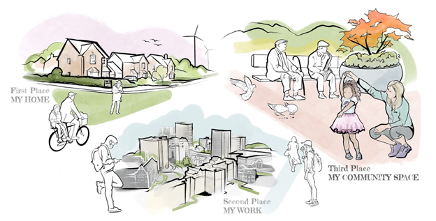

Figure 1: A depiction of first, second, and places: My Third Space (Freeman 2021)

However, recent times have seen a noticeable decline in these physical third places. This shift raises concerns about the potential weakening of community bonds and erosion of social cohesion. The decline is multifaceted, stemming from various socioeconomic, technological, and managerial factors.

Our investigation sought to understand the complex interplay of factors contributing to the reduced prominence of these vital community spaces. As Yuen & Johnson (2016) noted, technological advancements and the evolving concept of third places as diverse spaces play a significant role. Socioeconomic disparities, including higher poverty rates and racial disadvantages, also significantly impact the availability and sustainability of these third places, as highlighted by Rhubart et al. (2022).

Operational limitations, such as restrictive hours, limited leadership opportunities, and control issues, particularly affect potential third places like senior centers (Hutchinson and Gallant 2016). Furthermore, the infrastructure and leadership of a site, including the physical setup and the presence of a supportive director or champion, are crucial for success, especially for older adults (Northridge et al. 2016).

In the digital realm, online third places face challenges related to social density, equity, and personalization. Managing unintended consequences is vital for fostering well-being in these virtual spaces (Parkinson, Schuster, and Mulcahy 2021). The role of third places in community cohesion and economic impact, especially in rural areas where establishments like pubs are central, is critical; their loss could lead to significant community disruption (Cabras and Mount 2017).

Aldosemani et al. (2015) argue that preventing the loss of third places requires continuous evaluation and management, focusing on the space, users, activities, and the organization’s needs, goals, and resources.

## Trifecta

Recognizing the critical role of socializing in combating loneliness and the challenges posed by the decline of traditional social spaces, we sought to develop a sustainable solution that would foster social engagement and community building.

Building on our understanding of the detrimental impact of loneliness and the need for accessible social spaces, we introduce the innovative “Trifecta” model. This model serves as the cornerstone of our strategy to revitalize social interaction and community connections. The Trifecta represents a collaborative partnership among three key stakeholders: individual users, local businesses, and corporations. Each stakeholder plays a pivotal role in our ecosystem, creating a mutually beneficial relationship that addresses the identified challenges.

The Trifecta operates as follows:

*Individual Users*: Central to the Trifecta model are the individual users who often face barriers to socializing, including financial constraints, limited access to welcoming spaces, and logistical challenges in organizing and participating in social activities. Our platform empowers these users by providing easy access to a diverse array of local events that align with their interests. This facilitates opportunities for socialization, community engagement, and personal growth, all at no cost to the user.

In our approach, we view individual users as active contributors to the community ecosystem, not merely passive participants. Recognizing the diversity of needs within our user base, we cater to a wide range of demographic groups, including variations in age, cultural background, and socioeconomic status. We prioritize the availability of events that are affordable, free, and accessible. Additionally, we integrate a robust feedback mechanism into our platform, enabling users to rate events, offer suggestions, and express their specific needs. This continuous feedback loop is crucial for shaping an inclusive and responsive event landscape that genuinely resonates with and effectively serves the diverse needs of our community.

*Local Businesses*: Local businesses are integral to the Trifecta, serving as vital hubs for community engagement and development. Our model encourages local businesses to host and participate in community-driven events, workshops, and social gatherings aligned with local interests and values. The economic benefits for participating businesses are numerous, including increased customer loyalty, heightened community goodwill, and potential collaborations with other local entities. This approach not only revitalizes local economies but also strengthens the social fabric of the communities they serve.

*Corporations*: Corporations comprise the third element of the Trifecta, playing a crucial role in financing these social events. In a landscape where traditional and digital marketing methods are increasingly saturated, corporations are seeking more authentic and impactful ways to connect with potential customers. By sponsoring events that resonate with their brand and target audience, they achieve direct engagement with consumers, offering a novel approach to experiential marketing. Participating in the Trifecta model can also enhance a corporation’s Corporate Social Responsibility (CSR) strategy, bolstering brand image and fostering genuine connections with the community. This approach shifts the focus from traditional marketing tactics to fostering real-world impact and community support, aligning corporate objectives with societal well-being.

The Trifecta model harnesses the strengths and addresses the needs of each participant, creating a sustainable cycle. Within this cycle, users enjoy free and enriching social experiences, local businesses experience increased patronage and community involvement, and corporations find a novel and effective avenue for marketing. This approach not only revitalizes social spaces and combats loneliness but also fosters a sense of community and belonging, thus contributing to the social and economic well-being of local areas.

In essence, the Trifecta model expands the concept of experiential marketing, traditionally used by brands for targeted consumer engagement, to a broader, community-focused scale. This approach goes beyond promoting products or services; it nurtures a sense of community and belonging among consumers. By leveraging corporate sponsorships to facilitate accessible and inclusive events, experiential marketing becomes a powerful tool for social revitalization. This strategy aligns the interests of businesses with the fundamental human need for connection and community. Corporations gain authentic engagement and visibility by sponsoring events that cater to diverse interests, while individuals enjoy enriching social experiences without financial burden. Local businesses also benefit from increased foot traffic and community integration, contributing to local economic vitality.

The Trifecta model, therefore, represents a multi-dimensional approach where experiential marketing is not merely a business strategy but also a catalyst for community building and social well-being. It reimagines the role of marketing in society, transforming it into a conduit for positive social change while still achieving significant business objectives.

## Marketing Solutions

Experiential marketing, a contemporary approach, offers a distinct alternative to traditional digital advertising. This approach centers on creating direct, engaging experiences for consumers, allowing them to interact personally with a brand. By employing tools like brand development, personalization, and dialogue, experiential marketing aims to satisfy active user motives and facilitate differentiation between products or services through direct experience. The five key approaches of sense, feel, think, act, and relate guide this process.

Despite its growing prominence, there is a notable lack of up-to-date and accessible research on experiential marketing. The academic and industry knowledge base has not kept pace with the rapid evolution of this marketing approach, leaving professionals and scholars with limited contemporary resources to fully understand and leverage its potential. As the marketing landscape continues to evolve, collaboration among researchers, practitioners, and educators is increasingly vital to bridge this gap and generate current insights and findings in experiential marketing.

Despite the relative scarcity of academic research, numerous companies have successfully employed experiential marketing strategies. PepsiCo, for example, has leveraged this approach for its Doritos brand with the “Doritos #BoldStage” event series. This platform provides emerging artists with opportunities to perform at major music festivals, creating a unique synergy between the brand and musicians.

Coachella, a renowned music festival, has become a prime venue for experiential marketing. Brands like Heineken, HP, and HP’s subsidiary, OMEN, create immersive installations, lounges, and activations that resonate with festival-goers, effectively enhancing brand awareness and affinity.

Nike’s “NRC (Nike Run Club) Home Run” events offer another example. By organizing group runs, fitness challenges, and workshops, Nike fosters a sense of community and belonging among fitness enthusiasts and loyal customers.

Even sports stadiums have embraced experiential marketing. Companies like Nike, Coca-Cola, AT&T, and Toyota sponsor halftime shows, offer product samples, and utilize stadium signage to create memorable interactions between fans and their brands.

These examples highlight the diverse ways in which companies are leveraging experiential marketing to connect with consumers on a deeper level, fostering engagement, and building brand loyalty.

## Recommendation Algorithm

### Methodology

#### Our Thinking Process

Before we had anything close to a dataset, we had to first decide on what we wanted our data to potentially look like. We found inspiration from a few different spreadsheets found on a website called “data.world”. These spreadsheets contained data on social events that took place around the world, as well as basic user data such as name, age, sex, etc. The data found in these spreadsheets was used in part to create our first iteration of training data for our recommender model.

We now had a basic structure for what we wanted our data to look like, but the data itself was still not very meaningful. The test variable and even many of the features were randomly generated just to quickly create sample data, and as a result, it was impossible to train our model to have an accuracy greater than 50%, regardless of the architecture. It was at this point that we decided to introduce a bias into the data. This would allow us to see if we could build a model that could detect and overfit according to the bias. Although overfitting is never the goal of a machine learning model, it is an important step to see if the model can recognize patterns in the data in making predictions. The bias that we introduced came in the form of the users’ distance from each of the events. The data was regenerated so that events took place in either New York City, Los Angeles, or Chicago, users were located in one of ten suburbs for each city, and an event was attended by a user only if the user lived in a suburb of the city in which the event was. With this bias now in play, we were able to create a model with over 95% training accuracy despite only having one hidden layer.

The biased data proved that the features we were using could be used to sufficiently train a model when meaningful data samples were used. This means that the next step was to find meaningful data. Our first attempt at this was to use IIT’s Suitable data. Suitable is an app that allows students to post their upcoming campus events, where other students can then RSVP to them. Additionally, students who attend can check into events on the app, allowing the hosts to see who attended each event. Given that IIT has this data on campus events, students, and which students attended each event, it seemed like a natural next step to ask them for access. The school did give us a spreadsheet containing a lot of information pertaining to the aforementioned, but unfortunately it proved to be less useful than we had initially anticipated. The Office of Campus of Life was able to give us ample data on the events that different student orgs hosted over the last few semesters, but they could not give us any student/user data. Additionally, many of the columns for the event data given to us were incomplete, making it very difficult to create usable features from their data.

After consulting some of our professors, we had the idea to use surrogate data that resembles the structure of our current data but contains more samples and was collected from meaningful sources. This surrogate data would allow us to work on the optimal architecture for the model and evaluate it using meaningful metrics. We chose the Netflix dataset found online (https://www.kaggle.com/datasets/netflix-inc/netflix-prize-data), which contains user preferences, movie descriptors, and the movies that each user has watched. In our context, each of these categories can be used as stand ins for user data, event data, and users’ attendance at events, respectively.

In adapting the Netflix Prize dataset for our event recommendation algorithm, we underwent a transformative process to align the data with the context of user preferences for events rather than Netflix shows. This modification was essential to tailor the dataset to the unique characteristics of our event recommender system. Here’s how we approached this transformation:

Firstly, we replaced the concept of Netflix shows with events. The training dataset, originally organized into files for each movie, now represents a diverse range of events. Each event file begins with an event ID followed by a colon. Subsequent lines within the file mirror the structure of the original dataset, featuring customer IDs, ratings (indicative of user interest in the event), and corresponding dates.

The customer IDs were retained, but the users now represent individuals interested in attending events rather than Netflix users rating shows. This shift allows us to capture user preferences in the context of events, providing a foundation for more targeted recommendations.

Similarly, the Movies File was adapted to Events File, with the format adjusted to accommodate event-specific details. The event IDs, analogous to movie IDs, now uniquely identify each event. The YearOfRelease was replaced with relevant information about the event, such as the date it occurred or was announced. The titles, reflecting Netflix movie titles in the original dataset, now pertain to event names in English.

Training a model on this dataset becomes crucial, as achieving high accuracy directly correlates with the effectiveness of our event recommender algorithm. The success of the model in accurately predicting user preferences for events in the qualifying dataset serves as a tangible metric for the reliability and precision of our recommendation system. In the future, our hope is that our app will have enough users to start generating our data. Then, the data will be used to keep updating the model, the better model will hopefully bring in more users, and a positive reinforcement loop will be created. Collecting large amounts of meaningful data is still our priority, so in the meantime it may be more beneficial to use simpler model architectures or perhaps less data intensive machine learning algorithms.

#### What Does an Ideal Dataset Look Like?

The data must contain features that pertain both to the users and the events.

User data mainly consists of three subcategories: physical features, personal features, and location. Physical features include the user’s age, sex, ethnicity, etc. Personal features include interests, hobbies, income, education, nationality, the categories of past events that the user attended, the number of times they attended an event belonging to each category, the time since the user last attended an event of each category, etc. Location consists of the city, state, zip code, country, latitude, and longitude of the user’s home address.

Event data consists of four subcategories: pertinence, historical data, details, and location. Pertinence is the degree of relevance of the event to specific users. This can include the event’s category, theme, or tags that align with the users’ interests and past attendance patterns. Historical data encompasses the event’s track record, such as its popularity, ratings, and reviews from previous attendees. Details involve specific information about the event, such as date, time, duration, and venue size.

Aside from the features listed above, we would like to be able to give our model as much information as possible to make a decision. For this reason, there is no upper limit to the number of features or type of features that the “ideal” data would contain. In practice, data will be largely shaped by what is available.

#### What Does an Ideal Classifier Look Like?

An ideal classifier for your event recommendation system should be capable of effectively matching user features and event characteristics. The classifier should accurately predict user preferences for events, minimizing false positives and negatives. High accuracy ensures that users receive recommendations that genuinely align with their interests.

#### What Does Our Data Look Like?

As we mentioned above, our data is largely impacted by what is available and affordable to our team. This may sound like an easy way to limit the scope of our data, but in truth, it was more complicated. When you are starting with nothing and have the endless resources of the internet at your disposal, determining what data is available, what data is meaningful, and what data will yield results is a tall order.

Our team eventually settled on a table of event data found on [data.world](https://data.world/) as our jumping off point. The table included columns for event names, descriptions, categories, locations, etc., and it provided an organized template for us to build our data on top of. After removing unnecessary features from the original dataset and adding some additional ones, we arrived at our table of event data.

Next, we had to come up with our user data. Like before, the user data is inspired by a table of peoples’ personal information that we found online. From there, we added features pertaining to the peoples’ interests. This portion of the data is largely influenced by the event categories we are dealing with. For example, we keep a count of the number of times each user went to an event in each category. We also count the number of days since the last time each user went to an event in each category.

The trickiest part was figuring out how to tie the two tables together. Each data sample needs to contain features for both an event and a user. The problem with this is that the relationship between events and users is many-to-many, so there is no efficient way to join the two tables together. Our solution was to simply make our training data the cartesian product of the events and users tables (see Figure 2). That way every user gets paired with every event. From there, we can label whether each user went to each individual event.

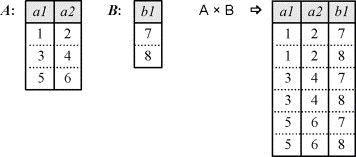

Figure 2: Cartesian Product

The dataset comprises event and user information, encompassing event names, types, timings, accessibility, cost, and geographical coordinates. Event categories cover community activities, arts and culture, music, etc., providing a comprehensive event characterization. User-centric data includes demographics (age, gender, marital status), attendance counts across categories, and location coordinates. The dataset aids in understanding user preferences and behaviors through demographic attributes and attendance counts. Latitude and longitude coordinates, along with transportation details, contribute to a holistic view of user locations. This combined information forms the foundation for developing a recommendation algorithm, capable of discerning patterns in user-event interactions and delivering personalized suggestions aligned with individual preferences and lifestyles.

#### What Are The Data Collection Methods?

The event recommendation system employs distinct data collection methods for both event and user data. The initial event data is sourced from data.world, featuring essential columns such as event names, descriptions, categories, and locations. Unnecessary features are removed, and additional relevant ones are incorporated. User data, inspired by an online table of personal information, includes demographics, interests, and features related to event categories. Specific user interest features, such as counts of event attendance in each category, are added. To address the many-to-many relationship between events and users, the training data is generated as the cartesian product of the events and users tables, ensuring every user is paired with every event.

In terms of data sharing, the comprehensive dataset encompasses both event and user information, providing a foundation for training the recommendation algorithm. The dataset includes details such as event names, types, timings, accessibility, cost, and geographical coordinates. User-centric data involves demographics, attendance counts across categories, and location coordinates.

The ideal classifier for the event recommendation system is one that effectively matches user features and event characteristics, accurately predicting user preferences with minimized false positives and negatives. Alternative architectures, such as Naive Bayes and Decision Trees, are considered and discarded based on their limitations in handling complex relationships and diverse data types.

In the data preprocessing phase, features are normalized to facilitate model convergence. The overarching goal is to develop a recommendation algorithm capable of discerning patterns in user-event interactions, delivering personalized suggestions aligned with individual preferences. This methodology strives to create a robust recommendation system by leveraging a diverse set of features from both event and user data, overcoming challenges related to the many-to-many relationship between events and users.

### Data Preprocessing

The dataset $D$ comprises $N$ samples, each characterized by features $\mathbf{X}_i$ and binary labels $Y_i$, including categories, counts, and attendance metrics. Features are normalized to facilitate model convergence.

### Alternative Architectures

#### Naive Bayes

Naive Bayes classifiers are known for their simplicity and efficiency, making them suitable for certain recommendation scenarios.

Naive Bayes relies on the assumption of feature independence, which might not hold true for the complex relationships between various user and event features in our dataset. This assumption could oversimplify the underlying patterns, leading to less accurate predictions. Naive Bayes models may not capture intricate interactions and non-linearities present in the data. Given the diverse and dynamic nature of user preferences for events, we opted for models with greater expressiveness, such as neural networks.

#### Decision Trees

Decision trees are intuitive, interpretable, and capable of handling both numerical and categorical data. They can be useful for uncovering decision rules in a dataset (see Figure 3).

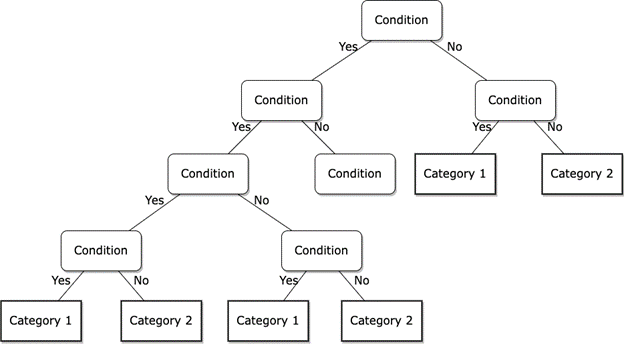

Figure 3: A Decision Tree

Decision trees do not explicitly offer probabilities in the same way that neural network models designed for probability estimation, like logistic regression or models with softmax (σ) activation, do. They instead generate discrete results. Decision trees might not handle continuous data as effectively as other models. Given that our dataset includes a mix of categorical and continuous features, we favored models capable of handling this diversity seamlessly. Decision trees are prone to overfitting, especially with complex datasets. Our dataset, consisting of diverse user and event features, might lead to the creation of overly detailed and specific rules that do not generalize well to new data. Meanwhile, the challenge with neural networks is with the model architecture and the amount of data as opposed to the risk of overfitting by using decision trees.

#### Neural Network Architecture

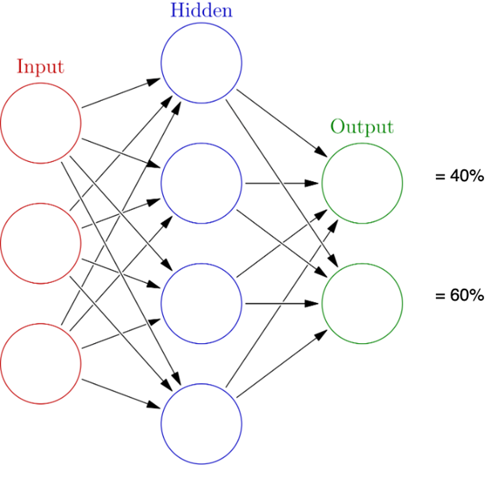

Figure 4: A Neural Network

Neural networks, inspired by the human brain, consist of interconnected layers of nodes (neurons) that process information. The deep architecture allows the model to learn hierarchical representations, capturing complex relationships within the data.

In our model:

- Input Layer: Captures user and event features.
- Hidden Layers: Enable the model to learn hierarchical representations.
- Output Layer: Produces binary predictions.

This architecture, coupled with the sigmoid activation, facilitates the model’s ability to provide nuanced and accurate event recommendations based on user preferences and behaviors.

The model predicts the probability that a user will attend an event, offering a quantitative measure of the likelihood of user engagement with suggested activities.

### Training

$$L(y, \hat{y}) = - (y \log{\hat{y}} + (1 - y) \log(1 - \hat{y}))$$

In conclusion, our approach involves a thorough exploration of alternative algorithms and the utilization of a deep neural network to enhance the effectiveness of our event recommendation system. The model’s architecture and activation function are tailored to capture intricate patterns and deliver personalized suggestions aligned with individual preferences and lifestyles.

Our model evaluation results are as follows:

- RMSE (Root Mean Square Error): 1.2294
- Precision: 0.8612
- Recall: 0.8298
- F1 Score: 0.8452

These results validate our hypothesis that a deep neural network, tailored for event recommendation succeeds in recommending events users are most likely to attend based on their previous patterns.

## Future Developments

The digital age, while revolutionizing communication and connectivity, has paradoxically exacerbated feelings of loneliness and isolation. As technology increasingly mediates social interaction, the gap between digital connection and real-world engagement widens. This necessitates a comprehensive exploration of innovative solutions that address the multifaceted issue of loneliness in the digital era.

A multi-pronged approach integrating technology, marketing, and social strategies may provide a viable framework for intervention. Technological advancements could include the development of virtual communities on existing social platforms, personalized recommendations using AI-driven algorithms, and the integration of wearable technology to promote physical activity and social behavior.

Marketing and outreach initiatives could target individuals at higher risk of loneliness, utilizing personalized content and collaborations with influencers to raise awareness and reduce stigma. Fostering a sense of community through online and offline events could further enhance social connection and belonging.

Further research is needed to explore the efficacy of these proposed interventions. A deeper understanding of social behaviors and trends through data analytics could refine intervention strategies, while cross-platform integration could enhance accessibility and user engagement. Real-time user feedback mechanisms could continuously inform and improve the effectiveness of interventions.

Moreover, integrating mental health support into these initiatives could address the psychological aspects of loneliness, offering a more holistic approach. Future research could also delve into the potential of emerging technologies, such as virtual reality and augmented reality, to create immersive social experiences and bridge the digital-physical divide.

Addressing loneliness in the digital age demands a multi-faceted approach that embraces technological innovation, targeted outreach, and community-building initiatives. By exploring these avenues and incorporating user feedback, we can develop effective interventions that foster genuine connections and mitigate the negative impact of loneliness in an increasingly digital world.

# References

Aldosemani, Tahani Ibrahim, Craig Erschel Shepherd, Ibrahim Gashim, and Tonia Dousay. 2015. “Developing Third Places to Foster Sense of Community in Online Instruction.” *British Journal of Educational Technology* 47 (6): 1020–31. https://doi.org/10.1111/bjet.12315.

Bekhet, Abir K., and Jaclene A. Zauszniewski. 2012. “Mental Health of Elders in Retirement Communities: Is Loneliness a Key Factor?” *Archives of Psychiatric Nursing* 26 (3): 214–24. https://doi.org/10.1016/j.apnu.2011.09.007.

Berg-Weger, M., and John E. Morley. 2020. “Loneliness in Old Age: An Unaddressed Health Problem.” *The Journal of Nutrition, Health & Aging* 24 (3): 243–45. https://doi.org/10.1007/s12603-020-1323-6.

Boursier, Valentina, Francesca Gioia, Alessandro Musetti, and Adriano Schimmenti. 2020. “Facing Loneliness and Anxiety During the COVID-19 Isolation: The Role of Excessive Social Media Use in a Sample of Italian Adults.” *Frontiers in Psychiatry* 11. https://doi.org/10.3389/fpsyt.2020.586222.

Cabras, Ignazio, and Matthew P. Mount. 2017. “How Third Places Foster and Shape Community Cohesion, Economic Development and Social Capital: The Case of Pubs in Rural Ireland.” *Journal of Rural Studies* 55: 71–82. https://doi.org/10.1016/j.jrurstud.2017.07.013.

Campagne, Daniel M. 2019. “Stress and Perceived Social Isolation (Loneliness.” *Archives of Gerontology and Geriatrics* 82 (May): 192–99. https://doi.org/10.1016/j.archger.2019.02.007.

Cela, Eralba, and Tineke Fokkema. 2016. “Being Lonely Later in Life: A Qualitative Study Among Albanians and Moroccans in Italy.” *Ageing and Society* 37 (6): 1197–1226. https://doi.org/10.1017/s0144686x16000209.

Crewdson, None James Alexander. 2016. “The Effect of Loneliness in the Elderly Population: A Review.” *Healthy Aging & Clinical Care in the Elderly* 8 (January): 1–8. https://doi.org/10.4137/hacce.s35890.

Finley, Anna J., and Stacey M. Schaefer. 2022. “Affective Neuroscience of Loneliness: Potential Mechanisms Underlying the Association Between Perceived Social Isolation, Health, and Well-Being.” *Journal of Psychiatry and Brain Science* 7 (6). https://doi.org/10.20900/jpbs.20220011.

Freeman, Beatrice. 2021. “My Third Place - a Community Legacy.” https://www.linkedin.com/pulse/my-third-place-community-legacy-beatrice-freeman/.

Gerino, Eva, Luca Rollè, Cristina Sechi, and Piera Brustia. 2017. “Loneliness, Resilience, Mental Health, and Quality of Life in Old Age: A Structural Equation Model.” *Frontiers in Psychology* 8 (November). https://doi.org/10.3389/fpsyg.2017.02003.

“GROUPS 4 HEALTH Reduces Loneliness and Social Anxiety in Adults with Psychological Distress: Findings from a Randomized Controlled Trial.” n.d. *Journal of Consulting and Clinical Psychology* 9 (September 1, 2019): 787–801. https://doi.org/10.1037/ccp0000427.

Helm, Peter J., Tyler Jimenez, Madhwa S. Galgali, Megan E. Edwards, Kenneth E. Vail, and Jamie Arndt. 2022. “Divergent Effects of Social Media Use on Meaning in Life via Loneliness and Existential Isolation During the Coronavirus Pandemic.” *Journal of Social and Personal Relationships* 39 (6): 1768–93. https://doi.org/10.1177/02654075211066922.

Hutchinson, Susan L., and Karen A. Gallant. 2016. “Can Senior Centres Be Contexts for Aging in Third Places.” *Journal of Leisure Research* 48 (1): 50–68. https://doi.org/10.18666/jlr-2016-v48-i1-6263.

Khademi, Mohammad, Vahid Rashedi, Seyed Mohammad Sajadi, and Shirzad Gheshlaghi. 2015. “Anxiety and Loneliness in the Iranian Older Adults.” *International Journal of Psychology and Behavioral Sciences* 5 (March): 49–52. https://doi.org/10.5923/j.ijpbs.20150502.01.

Northridge, Mary E., Susan S. Kum, Bibhas Chakraborty, Ariel Port Greenblatt, Stephen E. Marshall, Hua Wang, Carol Kunzel, and Sara S. Metcalf. 2016. “Third Places for Health Promotion with Older Adults: Using the Consolidated Framework for Implementation Research to Enhance Program Implementation and Evaluation.” *Journal of Urban Health* 93 (5): 851–70. https://doi.org/10.1007/s11524-016-0070-9.

O’Day, Emily B., Rachel M. Butler, Amanda S. Morrison, Philippe R. Goldin, James J. Gross, and Richard G. Heimberg. 2021. “Reductions in Social Anxiety During Treatment Predict Lower Levels of Loneliness During Follow-up Among Individuals with Social Anxiety Disorder.” *Journal of Anxiety Disorders* 78 (March): 102362. https://doi.org/10.1016/j.janxdis.2021.102362.

Pai, Nagesh, and Shae-Leigh Vella. 2022. “The Physical and Mental Health Consequences of Social Isolation and Loneliness in the Context of COVID-19.” *Current Opinion in Psychiatry* 35 (5): 305–10. https://doi.org/10.1097/yco.0000000000000806.

Parkinson, Joy, Lisa Schuster, and Rory Mulcahy. 2021. “Online Third Places: Supporting Well-Being Through Identifying and Managing Unintended Consequences.” *Journal of Service Research* 25 (1): 108–25. https://doi.org/10.1177/10946705211018860.

Rhubart, Danielle, Yue Sun, Claire Pendergrast, and Shannon Monnat. 2022. “Sociospatial Disparities in ‘Third Place’ Availability in the United States.” *Socius* 8 (January): 237802312210903. https://doi.org/10.1177/23780231221090301.

Richard, Aline, Sabine Rohrmann, Caroline L. Vandeleur, Margareta Schmid, Jürgen Barth, and Monika Eichholzer. 2017. “Loneliness Is Adversely Associated with Physical and Mental Health and Lifestyle Factors: Results from a Swiss National Survey.” *PloS One* 12 (7): 0181442. https://doi.org/10.1371/journal.pone.0181442.

Santini, Ziggi Ivan, Katherine Leigh Fiori, Joanne Feeney, Stefanos Tyrovolas, Josep Maria Haro, and Ai Koyanagi. 2016. “Social Relationships, Loneliness, and Mental Health Among Older Men and Women in Ireland: A Prospective Community-Based Study.” *Journal of Affective Disorders* 204 (November): 59–69. https://doi.org/10.1016/j.jad.2016.06.032.

Solomonov, Nili, Jennifer N. Bress, Jo Anne Sirey, Faith M. Gunning, Christoph Flückiger, Patrick J. Raue, Patricia A. Areán, and George S. Alexopoulos. 2019. “Engagement in Socially and Interpersonally Rewarding Activities as a Predictor of Outcome in ‘Engage’ Behavioral Activation Therapy for Late-Life Depression.” *American Journal of Geriatric Psychiatry/the American Journal of Geriatric Psychiatry* 27 (6): 571–78. https://doi.org/10.1016/j.jagp.2018.12.033.

Twenge, Jean M., Brian H. Spitzberg, and W.Keith Campbell. 2019. “Less in-Person Social Interaction with Peers Among u.s. Adolescents in the 21st Century and Links to Loneliness.” *Journal of Social and Personal Relationships* 36 (6): 1892–1913. https://doi.org/10.1177/0265407519836170.

Yuen, Felice, and Amanda J. Johnson. 2016. “Leisure Spaces, Community, and Third Places.” *Leisure Sciences* 39 (3): 295–303. https://doi.org/10.1080/01490400.2016.1165638.

[^1]: Contact the author.
[^2]: Contact the author.
[^3]: Contact the author.
[^4]: Contact the author.